# Bagging Analysis

This notebook examines the robustness of `k-means++` for creating bags for distribution regression, and compares bags created with all observations in a voterfile v. just those observed in a survey.

## Read in data, set parameters.

```r
survey_vars = c('demo_mode', 'demo_education', 'demo_phonetype', 'month_called', 'demo_ideology', 'demo_party')
file_and_survey_vars = c('demo_sex', 'demo_age_bucket', 'demo_state', 'demo_income', 'demo_region', 'demo_race', 'demo_hispanic')

# read in *recoded* data
pew_data = fread('../data/pew_data.csv')

# set n_bags
n_bags = 30
```

## get test train sets

```r
testtrain = getTestTrain(data = pew_data
                         , n_holdout = 1000, n_surveyed = 2000, n_matched = 1000
                         , p_surveyed = pew_data$p_surveyed
                         , p_matched = pew_data$p_matched
)
pew_data[, .(.N, mean(y_dem)), .(holdout, surveyed, matched, voterfile)]
```

| holdout | surveyed | matched | voterfile | N | V2 |
| --- | --- | --- | --- | --- | --- |
| 0 | 0 | 0 | 1 | 2259 | 0.4772023 |
| 0 | 1 | 1 | 1 | 1000 | 0.4750000 |
| 0 | 1 | 0 | 0 | 1000 | 0.5090000 |
| 1 | 0 | 0 | 0 | 1000 | 0.4960000 |

## What data - survey or full file?

### Run simulation

Run `k-means++` 50 times to generate bags using each 1) all the voterfile observations and 2) just the survey data.

```r
bag_iter = 50
bag_svy_mat = matrix(rep(0, bag_iter * nrow(pew_data)), nrow = nrow(pew_data))
bag_all_mat = matrix(rep(0, bag_iter * nrow(pew_data)), nrow = nrow(pew_data))

for(i in 1:bag_iter){
  cat(paste(i, '\n'))
  bag_svy_mat[,i] = getBags(data = pew_data[surveyed == 1, ]
                         , vars = file_and_survey_vars
                         , n_bags = n_bags
                         , newdata = pew_data)$bags_newdata
  bag_all_mat[,i] = getBags(data = pew_data[holdout == 0, ]
                     , vars = file_and_survey_vars
                     , n_bags = n_bags
                     , newdata = pew_data)$bags_newdata

}
```

[output not shown]

```r
bag_svy_mat = melt(bag_svy_mat, varnames = c('id', 'iter'), value.name = 'bag_svy')
bag_all_mat = melt(bag_all_mat, varnames = c('id', 'iter'), value.name = 'bag_all')
bag_mat = data.table(merge(bag_svy_mat, bag_all_mat, by = c('id','iter')))
```

### Bag size

We want to know if generating bags based on just the survey data leads to imbalances in bag size when bags are assigned to the full voterfile, and vice-versa. We see that the distribution of bag sizes for the whole voterfile is consistent across data used to generate the bags. However, when we look at the distrbution of bag sizes within just the observations that were surveyed, we see less variability in bag size when the bags are generated with just the survey data than with the full voterfile.

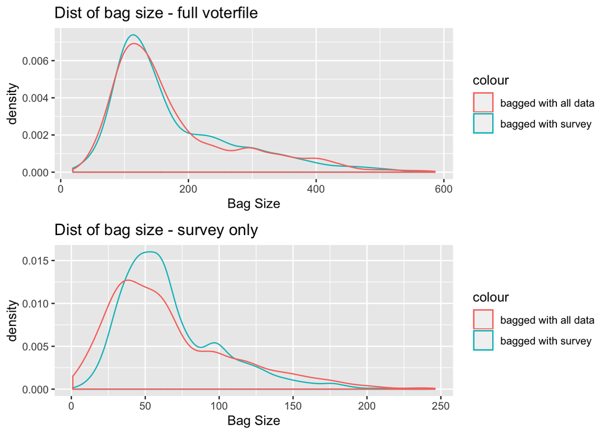

```r
plot_bagsize_all = ggplot() +
  geom_density(aes(bag_mat[, .(.N), .(bag_svy, iter)]$N, color = 'bagged with survey')) +
  geom_density(aes(bag_mat[, .(.N), .(bag_all, iter)]$N, color = 'bagged with all data')) +
  xlab("Bag Size") +
  ggtitle("Dist of bag size - full voterfile")

plot_bagsize_svy = ggplot() +
  geom_density(aes(bag_mat[id %in% pew_data[, which(surveyed == 1)], .(.N), .(bag_svy, iter)]$N, color = 'bagged with survey')) +
  geom_density(aes(bag_mat[id %in% pew_data[, which(surveyed == 1)], .(.N), .(bag_all, iter)]$N, color = 'bagged with all data')) +
  xlab("Bag Size") +
  ggtitle("Dist of bag size - survey only")

grid.arrange(plot_bagsize_all, plot_bagsize_svy)
```

### Empty bags

We also want to make sure that when we’re generating bags with the voterfile data, those bags aren’t empty in the survey data (which would leave us without an estimate of the outcome in that bag). Simlarly, when we generate the bags with just the survey data, we want to make sure that no bags are missing from the voterfile data, which would force us to throw away outcome data.

NOTE: I’ve seen some simulation runs with empty bags when all data is used for bagging, but most of the time there aren’t any empty. This probably depends on the ratio of survey data to voterfile data - easier for there to be missing bags when defined by the voterfile and survey data is much smaller.

```r
bag_mat[id %in% pew_data[, which(surveyed == 1)], .(length(unique(bag_svy)), length(unique(bag_all))), iter][, .(min_bag_svy = min(V1), min_bag_all = min(V2))]
```

| min_bag_svy | min_bag_all |
| --- | --- |
| 30 | 30 |

### Bag similarity

Let’s look at what proportion of the time that pairs of observations end up in the same bags as one another.

Heavy tail indicates that some pairs almost always end up together, though mode at 0 - most never overlap, or overlap only a few times. No real difference in overlap patterns depending on which data is used to bag.

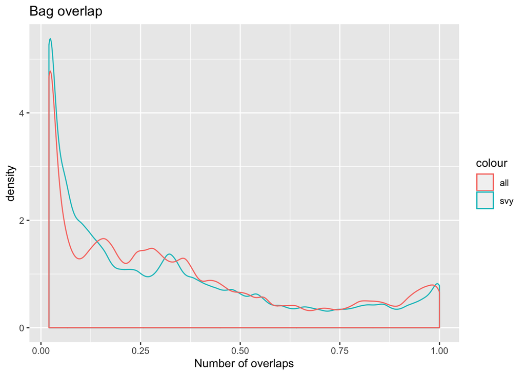

```r
bag_mat[, iter_bag_svy := interaction(iter, bag_svy)]
bag_mat[, iter_bag_all := interaction(iter, bag_all)]

bag_svy_overlap = merge(bag_mat, bag_mat, by = 'iter_bag_svy', allow.cartesian=TRUE)[, .N, by = .(id.x,id.y)]
bag_all_overlap = merge(bag_mat, bag_mat, by = 'iter_bag_all', allow.cartesian=TRUE)[, .N, by = .(id.x,id.y)]

ggplot() +
  geom_density(data = bag_svy_overlap[id.x != id.y,], aes(x = N/50, color = 'svy')) +
  geom_density(data = bag_all_overlap[id.x != id.y,], aes(x = N/50, color = 'all')) +
  ggtitle("Bag overlap") +
  xlab("Number of overlaps")
```

## Which variables

### Run simulation

Run `k-means++` 50 times to generate bags using each 1) the variables that exist both on the file and the survey AND those just on the survey 2) just the overlapping variables. In the first version, we assign observations to bags only using the overlapping variables (even for the survey data).

```r
bag_iter = 50
bag_allvars_mat = matrix(rep(0, bag_iter * nrow(pew_data)), nrow = nrow(pew_data))
bag_svyvars_mat = matrix(rep(0, bag_iter * nrow(pew_data)), nrow = nrow(pew_data))


for(i in 1:bag_iter){
  cat(paste(i, '\n'))

  ### VERSION 1 - ALL VARS
  bags_temp = getBags(data = pew_data[surveyed == 1, ]
                         , vars = c(survey_vars, file_and_survey_vars)
                         , n_bags = n_bags)

  # get cols of just the overlapping vars
  modmat_fmla = as.formula(paste('~', paste(file_and_survey_vars, collapse = '+')))
  X = modmat_all_levs(data = pew_data, formula = modmat_fmla)

  #limit centers to just those cols
  bags_temp$bag_fit$centers = bags_temp$bag_fit$centers[, which(colnames(bags_temp$bag_fit$centers) %in% colnames(X))]

  # fit bags with limited centers
  bag_allvars_mat[, i] = getBags(bags = bags_temp$bag_fit
                                 , vars = file_and_survey_vars
                                 , newdata = pew_data)$bags_newdata

  ### VERSION 2 - just overlapping vars
  bag_svyvars_mat[, i] = getBags(data = pew_data[surveyed == 1, ]
                         , vars = file_and_survey_vars
                         , n_bags = n_bags
                         , newdata = pew_data)$bags_newdata
}
```

[output not shown]

```r
bag_svyvars_mat_v2 = melt(bag_svyvars_mat, varnames = c('id', 'iter'), value.name = 'bag_overlaponly')
bag_allvars_mat_v2 = melt(bag_allvars_mat, varnames = c('id', 'iter'), value.name = 'bag_allvars')
bag_vars_mat = data.table(merge(bag_svyvars_mat_v2, bag_allvars_mat_v2, by = c('id','iter')))
```

### Distribution of bag sizes

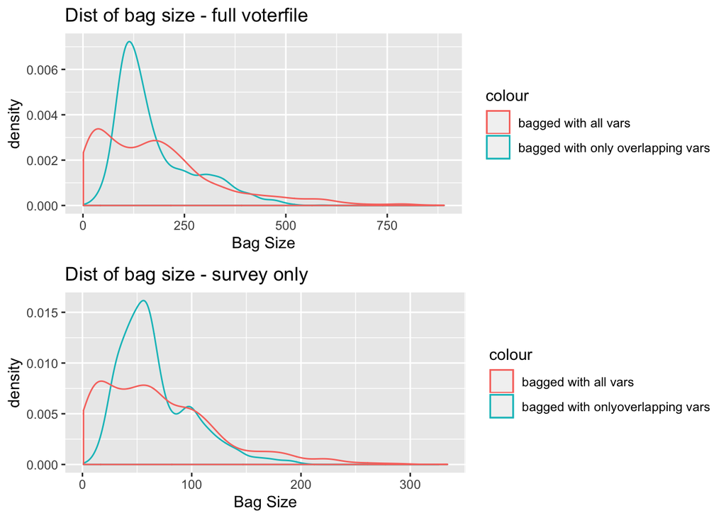

```r
plot_bagsize_vars_all = ggplot() +
  geom_density(aes(bag_vars_mat[, .(.N), .(bag_overlaponly, iter)]$N, color = 'bagged with only overlapping vars')) +
  geom_density(aes(bag_vars_mat[, .(.N), .(bag_allvars, iter)]$N, color = 'bagged with all vars')) +
  xlab("Bag Size") +
  ggtitle("Dist of bag size - full voterfile")

plot_bagsize_vars_svy = ggplot() +
  geom_density(aes(bag_vars_mat[id %in% pew_data[, which(surveyed == 1)], .(.N), .(bag_overlaponly, iter)]$N, color = 'bagged with onlyoverlapping vars')) +
  geom_density(aes(bag_vars_mat[id %in% pew_data[, which(surveyed == 1)], .(.N), .(bag_allvars, iter)]$N, color = 'bagged with all vars')) +
  xlab("Bag Size") +
  ggtitle("Dist of bag size - survey only")

grid.arrange(plot_bagsize_vars_all, plot_bagsize_vars_svy)
```

### Empty bags

When we use all the variables to make bags and assign just with the overlapping variables, we end up with empty bags in both the survey and the voterfile. If instad we assigned survey observations to bags using all the variables, we’d end up throwing out the outcome data for bags that don’t exist in the voterfile.

```r
bag_vars_mat[, .(length(unique(bag_overlaponly)), length(unique(bag_allvars))), iter][, .(min_bag_svy = min(V1), min_bag_all = min(V2))]
```

| min_bag_svy | min_bag_all |
| --- | --- |
| 30 | 27 |